# filtering_explore

# 4 Model Sample Design

- Model experimental design

```r
## default Gr_1 and Gr_2 to Gr
## remove NKG2A_blah NK subtype, which were collected in late timepoints

mytargets <-ZG66_bq_min$metadata %>%
  select(Celltype, Months) %>%
  mutate(Phase = ifelse(Months < 6, "early", ifelse(Months >=55, "late", "mid"))) %>%
  mutate(Celltype = gsub("(Gr).*", "\\1", Celltype))

## trim samples - exclude early and late time samples, keeping only mid samples to test
## First filtering strategy
ZG66_test_min <- ZG66_bq_min
ZG66_test_min$metadata <- mytargets
ZG66_test_min <- barbieQ::subsetSamplesByMetadata(barbieQ = ZG66_test_min, factor = "Phase", specifiedConditions = "mid")
table(ZG66_test_min$metadata$Celltype)
```

```
##
##              B             Gr NK_CD56n_CD16p NK_CD56p_CD16n
##              6             12              7              7
##              T
##             10
```

```r
## Second filtering strategy
ZG66_test_0.9 <- ZG66_bq_0.9
ZG66_test_0.9$metadata <- mytargets
ZG66_test_0.9 <- barbieQ::subsetSamplesByMetadata(barbieQ = ZG66_test_0.9, factor = "Phase", specifiedConditions = "mid")
table(ZG66_test_0.9$metadata$Celltype)
```

```
##
##              B             Gr NK_CD56n_CD16p NK_CD56p_CD16n
##              6             12              7              7
##              T
##             10
```

```r
## load pre-filtering data
load("../../output/WuC/ZJ31_ZH33_ZG66_bq.rda")
ZG66_test <- ZG66_bq
ZG66_test$metadata <- mytargets
ZG66_test <- barbieQ::subsetSamplesByMetadata(barbieQ = ZG66_test, factor = "Phase", specifiedConditions = "mid")
table(ZG66_test$metadata$Celltype)
```

```
##
##              B             Gr NK_CD56n_CD16p NK_CD56p_CD16n
##              6             12              7              7
##              T
##             10
```

- Fit model

```r
## define matrix
## will consider Months factor later as each cell type may have different trend
mydesign <- model.matrix(~ 0 + Celltype, data = ZG66_test_min$metadata)
# View(mydesign)

## define contrast
mycontrast <- limma::makeContrasts(
  (CelltypeNK_CD56n_CD16p) - (CelltypeB+CelltypeGr+CelltypeT+CelltypeNK_CD56p_CD16n)/4,
  levels = colnames(mydesign))
```

```r
ZG66_test_min <- barbieQ::testBarcodeBias(
  barbieQ = ZG66_test_min,
  targets = ZG66_test_min$metadata,
  designMatrix = mydesign,
  contrast = mycontrast
  )
```

```
## setting Celltype as the primary effector of sample conditions.
```

```
## removing effectors with only one level from targets: NA
```

```
## testing barbieQ$proportion after arcsin square root transformation.
```

```
## no block specified, so there are no duplicate measurements.
```

```
## logFC is based on the data being tested, after being transformed.
```

```
## test methods saved in barbieQ$testBarcodes$methods.
```

```r
ZG66_test_min$testBarcodes$diffProp_Celltype$methods$groups
```

```
## [1] "(CelltypeNK_CD56n_CD16p)"
## [2] "(CelltypeB + CelltypeGr + CelltypeT + CelltypeNK_CD56p_CD16n)/4"
## [3] "NK_CD56n_CD16p"
## [4] "NK_CD56p_CD16n"
## [5] "T"
```

```r
ZG66_test_0.9 <- barbieQ::testBarcodeBias(
  barbieQ = ZG66_test_0.9,
  targets = ZG66_test_0.9$metadata,
  designMatrix = mydesign,
  contrast = mycontrast
  )
```

```
## setting Celltype as the primary effector of sample conditions.
```

```
## removing effectors with only one level from targets: NA
```

```
## testing barbieQ$proportion after arcsin square root transformation.
```

```
## no block specified, so there are no duplicate measurements.
```

```
## logFC is based on the data being tested, after being transformed.
```

```
## test methods saved in barbieQ$testBarcodes$methods.
```

```r
ZG66_test_0.9$testBarcodes$diffProp_Celltype$methods$groups
```

```
## [1] "(CelltypeNK_CD56n_CD16p)"
## [2] "(CelltypeB + CelltypeGr + CelltypeT + CelltypeNK_CD56p_CD16n)/4"
## [3] "NK_CD56n_CD16p"
## [4] "NK_CD56p_CD16n"
## [5] "T"
```

```r
ZG66_test <- barbieQ::testBarcodeBias(
  barbieQ = ZG66_test,
  designMatrix = mydesign,
  contrast = mycontrast
)
```

```
## setting Celltype as the primary effector of sample conditions.
```

```
## removing effectors with only one level from targets: NA
```

```
## testing barbieQ$proportion after arcsin square root transformation.
```

```
## no block specified, so there are no duplicate measurements.
```

```
## logFC is based on the data being tested, after being transformed.
```

```
## test methods saved in barbieQ$testBarcodes$methods.
```

```r
ZG66_test$testBarcodes$diffProp_Celltype$methods$groups
```

```
## [1] "(CelltypeNK_CD56n_CD16p)"
## [2] "(CelltypeB + CelltypeGr + CelltypeT + CelltypeNK_CD56p_CD16n)/4"
## [3] "NK_CD56n_CD16p"
## [4] "NK_CD56p_CD16n"
## [5] "T"
```

# 5 Compare Test Results

```r
ZG66_test_min$testBarcodes$diffProp_Celltype$results$direction %>% table()
```

```
## .
## group1 group2   n.s.
##    278    220   1169
```

```r
ZG66_test_0.9$testBarcodes$diffProp_Celltype$results$direction %>% table()
```

```
## .
## group1 group2   n.s.
##    273    297   1698
```

```r
ZG66_test$testBarcodes$diffProp_Celltype$results$direction %>% table()
```

```
## .
## group1 group2   n.s.
##    139    426  16038
```

```
## setting Celltype as the primary effector of sample conditions.
```

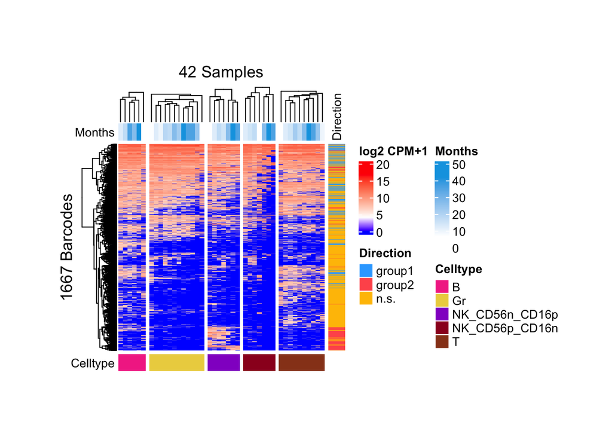

```r
barbieQ::plotBarcodeBiasHeatmap(ZG66_test_min)
```

```r
# barbieQ::plotBarcodeBiasHeatmap(ZG66_test_0.9)
```

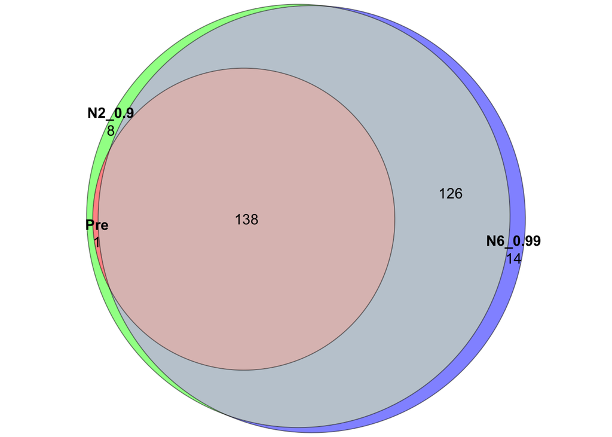

```r
plot(
  eulerr::euler(list(
    Pre = rownames(ZG66_test$assay)[ZG66_test$testBarcodes$diffProp_Celltype$results$direction == "group1"],
    N6_0.99 = rownames(ZG66_test_min$assay)[ZG66_test_min$testBarcodes$diffProp_Celltype$results$direction == "group1"],
    N2_0.9 = rownames(ZG66_test_0.9$assay)[ZG66_test_0.9$testBarcodes$diffProp_Celltype$results$direction == "group1"])),
  fills = c("red", "blue", "green"), alpha = 0.5, labels = TRUE, quantities = TRUE
  )
```

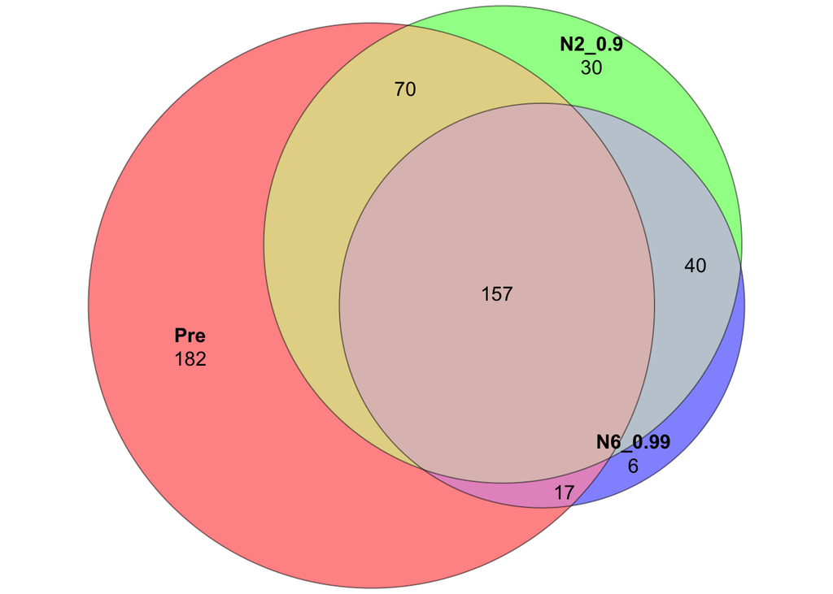

```r
plot(
  eulerr::euler(list(
    Pre = rownames(ZG66_test$assay)[ZG66_test$testBarcodes$diffProp_Celltype$results$direction == "group2"],
    N6_0.99 = rownames(ZG66_test_min$assay)[ZG66_test_min$testBarcodes$diffProp_Celltype$results$direction == "group2"],
    N2_0.9 = rownames(ZG66_test_0.9$assay)[ZG66_test_0.9$testBarcodes$diffProp_Celltype$results$direction == "group2"])),
  fills = c("red", "blue", "green"), alpha = 0.5, labels = TRUE, quantities = TRUE
  )
```

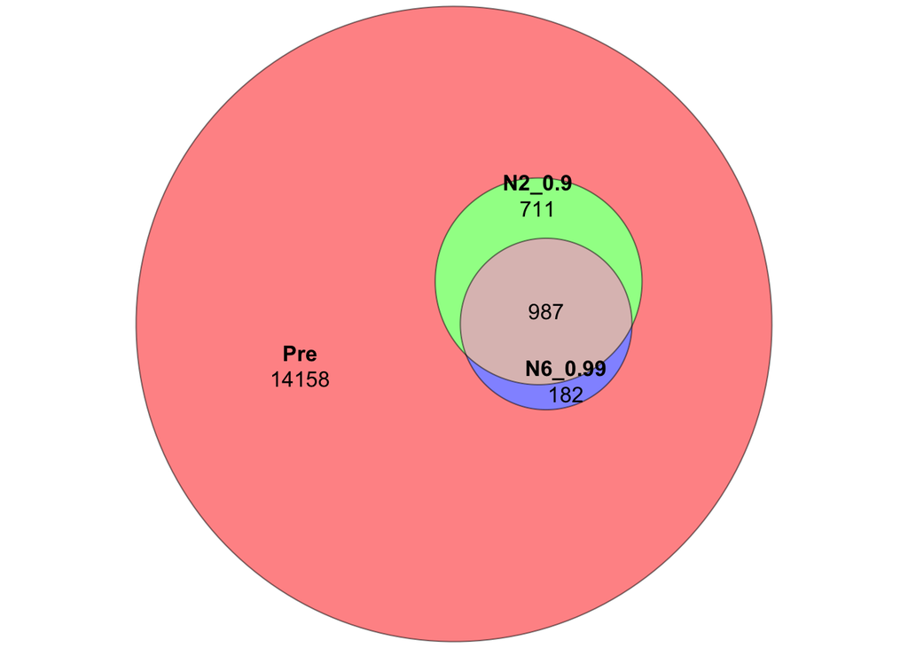

```r
plot(
  eulerr::euler(list(
    Pre = rownames(ZG66_test$assay)[ZG66_test$testBarcodes$diffProp_Celltype$results$direction == "n.s."],
    N6_0.99 = rownames(ZG66_test_min$assay)[ZG66_test_min$testBarcodes$diffProp_Celltype$results$direction == "n.s."],
    N2_0.9 = rownames(ZG66_test_0.9$assay)[ZG66_test_0.9$testBarcodes$diffProp_Celltype$results$direction == "n.s."])),
  fills = c("red", "blue", "green"), alpha = 0.5, labels = TRUE, quantities = TRUE
  )
```

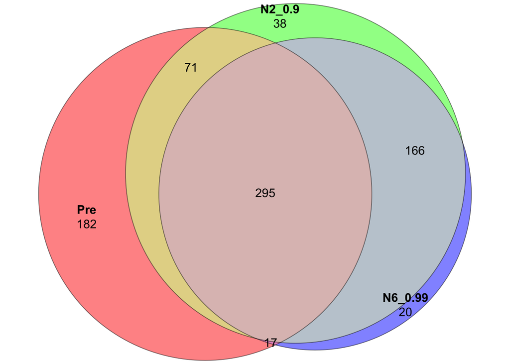

```r
plot(
  eulerr::euler(list(
    Pre = rownames(ZG66_test$assay)[ZG66_test$testBarcodes$diffProp_Celltype$results$direction != "n.s."],
    N6_0.99 = rownames(ZG66_test_min$assay)[ZG66_test_min$testBarcodes$diffProp_Celltype$results$direction != "n.s."],
    N2_0.9 = rownames(ZG66_test_0.9$assay)[ZG66_test_0.9$testBarcodes$diffProp_Celltype$results$direction != "n.s."])),
  fills = c("red", "blue", "green"), alpha = 0.5, labels = TRUE, quantities = TRUE
  )
```

# 6 All Relevant Barcodes

## 6.1 Sets of significant barcodes

- Retain barcodes being significant in unfiltered data, or being included in either the filtered data.
- Pointing based on the unfiltered data.

```r
pointer <- ZG66_test$testBarcodes$diffProp_Celltype$results$direction != "n.s." |
  rownames(ZG66_test$assay) %in% rownames(ZG66_test_min$assay) |
  rownames(ZG66_test$assay) %in% rownames(ZG66_test_0.9$assay)

sum(pointer)
```

```
## [1] 2653
```

```r
ZG66_all <- barbieQ::subsetBarcodes(barbieQ = ZG66_bq, retainedRows = pointer)

## make a big data.frame including all results
## extract test results from each
results_N6_0.99 <- ZG66_test_min$testBarcodes$diffProp_Celltype$results
colnames(results_N6_0.99) <- paste0("N6_0.99_", colnames(results_N6_0.99))
results_N2_0.9 <- ZG66_test_0.9$testBarcodes$diffProp_Celltype$results
colnames(results_N2_0.9) <- paste0("N2_0.9_", colnames(results_N2_0.9))
results_Pre <- ZG66_test$testBarcodes$diffProp_Celltype$results[pointer,]
colnames(results_Pre) <- paste0("Pre_", colnames(results_Pre))

## merge the results by rownames
results_all <- merge(results_Pre, results_N6_0.99, by = "row.names", all = TRUE)
rownames(results_all) <- results_all$Row.names
results_all <- results_all[, -1] # Remove the extra row names column

results_all <- merge(results_all, results_N2_0.9, by = "row.names", all = TRUE)
rownames(results_all) <- results_all$Row.names
results_all <- results_all[, -1] # Remove the extra row names column
## Order barcode in line with ZG66_all
results_all <- results_all[rownames(ZG66_all$assay),]
```

- In total, 789 barcodes are being tested as significant in either unfiltered data, or filtered data out of two strategies. Here we discuss significance based on **adjusted p.values**.
- From those, nearly 40% are consistently significant in the three data;
- around 20% are significant in both the filtered data but n.s in the unfiltered data;
- around 20% are significant in the unfiltered data, but n.s. in neither of the filtered data;
- the rest barcodes are either uniquely sig. in one data or sig. in other combos.
- For barcodes with p.values (**un-adjusted**) < 0.05 in the filtered data but >= 0.05 in the unfiltered data, this is unexpected in normal testing because each barcodes are independently tested. But here this phenomenon is because of the moderated t-test implemented in the limma model that the estimated variance is dependant on across the barcodes.

```r
ggVennDiagram::ggVennDiagram(
  x = list(
    Pre_sig = rownames(results_all)[!is.na(results_all$Pre_direction) & results_all$Pre_direction != "n.s."],
    N6_0.99_sig = rownames(results_all)[!is.na(results_all$N6_0.99_direction) & results_all$N6_0.99_direction != "n.s."],
    N2_0.9_sig = rownames(results_all)[!is.na(results_all$N2_0.9_direction) & results_all$N2_0.9_direction != "n.s."]),
  label = "both",
  # category.names = c("Pre", "N6_0.99", "N2_0.9"),
  label_size = 3,
  set_size = 3,
  force_upset = T
)
```

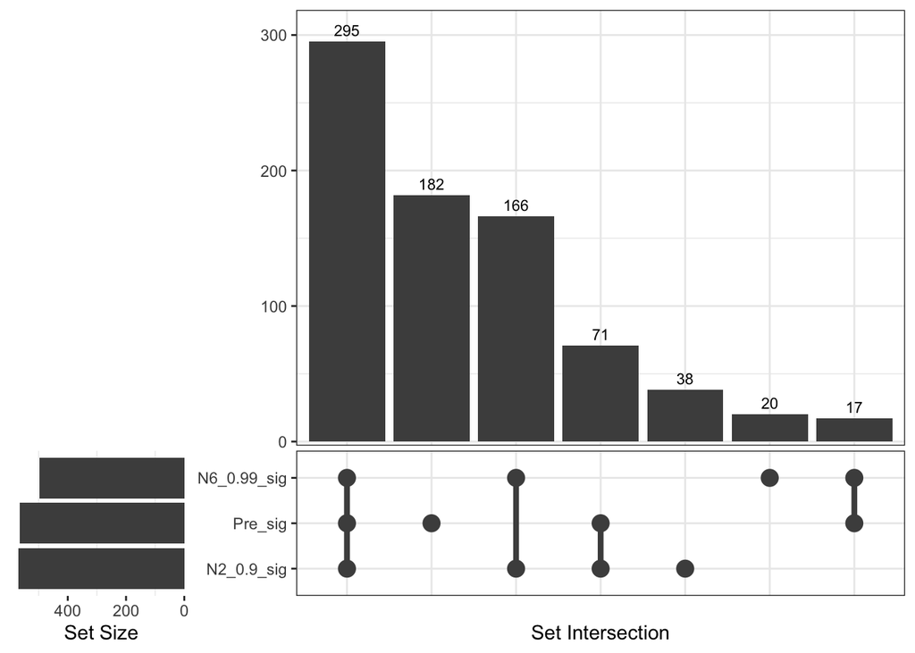

```r
ggVennDiagram::ggVennDiagram(
  x = list(
    Pre_sig = rownames(results_all)[!is.na(results_all$Pre_p.value) & results_all$Pre_p.value < 0.05],
    N6_0.99_sig = rownames(results_all)[!is.na(results_all$N6_0.99_p.value) & results_all$N6_0.99_p.value < 0.05],
    N2_0.9_sig = rownames(results_all)[!is.na(results_all$N2_0.9_p.value) & results_all$N2_0.9_p.value < 0.05]),
  label = "both",
  # category.names = c("Pre", "N6_0.99", "N2_0.9"),
  label_size = 3,
  set_size = 3,
  force_upset = T
)
```

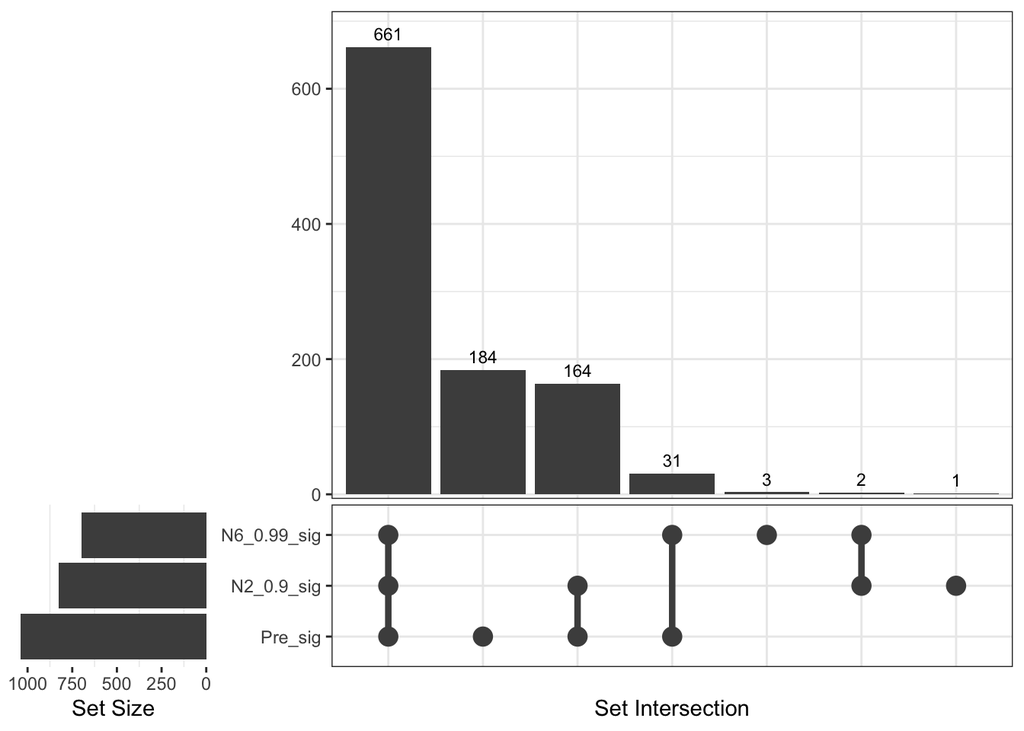

```r
## check the unexpected set.
# ttt <- ((!is.na(results_all$N6_0.99_p.value) & results_all$N6_0.99_p.value < 0.05) & (!is.na(results_all$Pre_p.value) & results_all$Pre_p.value >= 0.05) )
# View(results_all[ttt,])

ggVennDiagram::ggVennDiagram(
  x = list(
    Pre_Other = rownames(results_all)[!is.na(results_all$Pre_direction) & results_all$Pre_direction == "group1"],
    Pre_NK = rownames(results_all)[!is.na(results_all$Pre_direction) & results_all$Pre_direction == "group2"],

    N6_0.99_Other = rownames(results_all)[!is.na(results_all$N6_0.99_direction) & results_all$N6_0.99_direction == "group1"],
    N6_0.99_NK = rownames(results_all)[!is.na(results_all$N6_0.99_direction) & results_all$N6_0.99_direction == "group2"],

    N2_0.9_Other = rownames(results_all)[!is.na(results_all$N2_0.9_direction) & results_all$N2_0.9_direction == "group1"],
    N2_0.9_NK = rownames(results_all)[!is.na(results_all$N2_0.9_direction) & results_all$N2_0.9_direction == "group2"]),
  label = "both",
  # category.names = c("Pre", "N6_0.99", "N2_0.9"),
  label_size = 3,
  set_size = 3,
  force_upset = T
)
```

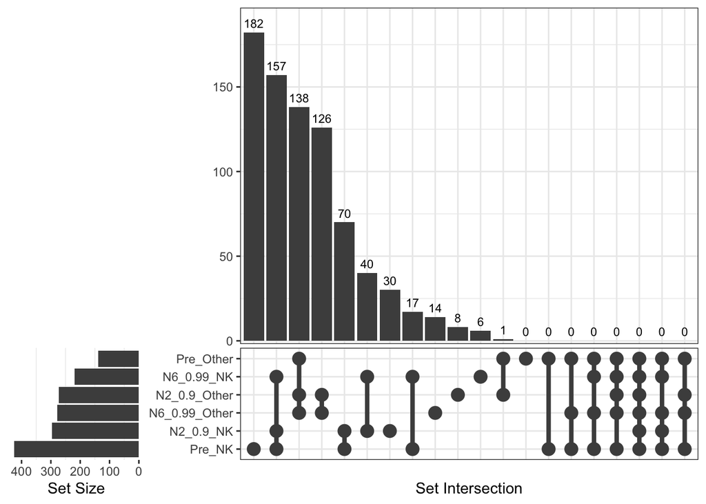

## 6.2 P.values of each set

```r
# Process the data for Venn diagram
cate_adj <- ggVennDiagram::process_data(
  Venn(
    list(
    Pre_sig = rownames(results_all)[!is.na(results_all$Pre_direction) & results_all$Pre_direction != "n.s."],
    N6_0.99_sig = rownames(results_all)[!is.na(results_all$N6_0.99_direction) & results_all$N6_0.99_direction != "n.s."],
    N2_0.9_sig = rownames(results_all)[!is.na(results_all$N2_0.9_direction) & results_all$N2_0.9_direction != "n.s."])
))
# Extract set (region) information (elements for each region)
region_info <- cate_adj$regionData
region_info$item[[1]] %>% class()
```

```
## [1] "character"
```

```r
long_region <- region_info %>%
  select(item, name) %>%         # Select relevant columns: items and region names
  unnest(item)              # Expand list-column `item` into rows
# rownames(long_region) <- long_region$item
# long_region <- long_region[,2, drop=FALSE]

## Merge sregion information with test results
results_all <- merge(results_all, long_region, by.x = "row.names", by.y = "item", all = TRUE)
colnames(results_all)[17] <- "region"
rownames(results_all) <- results_all$Row.names
results_all <- results_all[, -1]
## order results_all by ZG66_all
results_all <- results_all[rownames(ZG66_all$assay),]
```

- The most significant barcodes (with relatively low p.values) tend to be defined as “sig” in all pre-filtering and post-filtering data.

```r
## visualize adj.pvalues of different category
p11 <- ggplot(results_all) +
  geom_point(aes(x = rowMeans(ZG66_all$rank), y = Pre_adj.p.value, shape = Pre_direction, color = region)) +
  geom_hline(yintercept = 0.05, color = "red", linetype = "dashed", linewidth = 1) +
  ggtitle("Adjusted p.values from unfiltered data") +
  scale_x_reverse() +
  labs(x = "Average rank of each barcode across samples", y = "Adjusted p.values") +
  theme(legend.position = "none")

## visualize adj.pvalues of different category
p41 <- ggplot(results_all) +
  geom_point(aes(x = rowMeans(ZG66_all$rank), y = Pre_p.value, shape = Pre_direction, color = region)) +
  geom_hline(yintercept = 0.05, color = "red", linetype = "dashed", linewidth = 1) +
  ggtitle("P.values from unfiltered data") +
  scale_x_reverse() +
  labs(x = "Average rank of each barcode across samples", y = "P.values") +
  theme(legend.position = "none")

## visualize adj.pvalues of different category
p12 <- ggplot(results_all) +
  geom_point(aes(x = rowMeans(ZG66_all$rank), y = N6_0.99_adj.p.value, shape = N6_0.99_direction, color = region)) +
  geom_hline(yintercept = 0.05, color = "red", linetype = "dashed", linewidth = 1) +
  ggtitle("Adjusted p.values from data filtered by N6_0.99") +
  scale_x_reverse() +
  labs(x = "Average rank of each barcode across samples", y = "Adjusted p.values") +
  theme(legend.position = "none")

## visualize adj.pvalues of different category
p42 <- ggplot(results_all) +
  geom_point(aes(x = rowMeans(ZG66_all$rank), y = N6_0.99_p.value, shape = N6_0.99_direction, color = region)) +
  geom_hline(yintercept = 0.05, color = "red", linetype = "dashed", linewidth = 1) +
  ggtitle("P.values from data filtered by N6_0.99") +
  scale_x_reverse() +
  labs(x = "Average rank of each barcode across samples", y = "P.values") +
  theme(legend.position = "none")

## visualize adj.pvalues of different category
p13 <- ggplot(results_all) +
  geom_point(aes(x = rowMeans(ZG66_all$rank), y = N2_0.9_adj.p.value, shape = N2_0.9_direction, color = region)) +
  geom_hline(yintercept = 0.05, color = "red", linetype = "dashed", linewidth = 1) +
  ggtitle("Adjusted p.values from data filtered by N2_0.9") +
  scale_x_reverse() +
  labs(x = "Average rank of each barcode across samples", y = "Adjusted p.values") +
  theme(legend.position = "none")

## visualize adj.pvalues of different category
p43 <- ggplot(results_all) +
  geom_point(aes(x = rowMeans(ZG66_all$rank), y = N2_0.9_p.value, shape = N2_0.9_direction, color = region)) +
  geom_hline(yintercept = 0.05, color = "red", linetype = "dashed", linewidth = 1) +
  ggtitle("P.values from data filtered by N2_0.9") +
  scale_x_reverse() +
  labs(x = "Average rank of each barcode across samples", y = "P.values") +
  theme(legend.position = "none")
```

### 6.2.1 Zoom-in

```r
## flag barcodes that belongs to regions other than NA - which means being significant in at least pre/filter1/filter2 data
flag_sig <- !is.na(results_all$region)
sum(flag_sig)
```

```
## [1] 789
```

```r
identical(rownames(results_all), rownames(ZG66_all$assay))
```

```
## [1] TRUE
```

```r
## subset object by the flagged barcodes
ZG66_sig <- barbieQ::subsetBarcodes(barbieQ = ZG66_all, retainedRows = flag_sig)
results_sig <- results_all[flag_sig,]
p21 <- ggplot(results_sig) +
  geom_point(aes(x = rowMeans(ZG66_sig$rank), y = Pre_adj.p.value, shape = Pre_direction, color = region)) +
  geom_hline(yintercept = 0.05, color = "red", linetype = "dashed", linewidth = 1) +
  ggtitle("(Zoom in) adjusted p.values, unfiltered") +
  scale_x_reverse() +
  labs(x = "Average rank of each barcode across samples", y = "Adjusted p.values")

p22 <- ggplot(results_sig) +
  geom_point(aes(x = rowMeans(ZG66_sig$rank), y = N6_0.99_adj.p.value, shape = N6_0.99_direction, color = region)) +
  geom_hline(yintercept = 0.05, color = "red", linetype = "dashed", linewidth = 1) +
  ggtitle("(Zoom in) adjusted p.values, N6_0.99") +
  scale_x_reverse() +
  labs(x = "Average rank of each barcode across samples", y = "Adjusted p.values")

p23 <- ggplot(results_sig) +
  geom_point(aes(x = rowMeans(ZG66_sig$rank), y = N2_0.9_adj.p.value, shape = N2_0.9_direction, color = region)) +
  geom_hline(yintercept = 0.05, color = "red", linetype = "dashed", linewidth = 1) +
  ggtitle("(Zoom in) adjusted p.values, N2_0.9") +
  scale_x_reverse() +
  labs(x = "Average rank of each barcode across samples", y = "Adjusted p.values")
```

### 6.2.2 Volcano plots

```r
## visualize adj.pvalues of different category
p31 <- ggplot(results_all) +
  geom_point(aes(x = Pre_logFC, y = -log10(Pre_adj.p.value), shape = Pre_direction, color = region)) +
  geom_hline(yintercept = -log10(0.05), color = "red", linetype = "dashed", linewidth = 1) +
  ggtitle("volcano plot of unfiltered data") +
  labs(x = "Log fold change of barcode proportion between two groups", y = "-log10 (adjusted p.values)") +
  theme(legend.position = "none")

p32 <- ggplot(results_all) +
  geom_point(aes(x = Pre_logFC, y = -log10(N6_0.99_adj.p.value), shape = N6_0.99_direction, color = region)) +
  geom_hline(yintercept = -log10(0.05), color = "red", linetype = "dashed", linewidth = 1) +
  ggtitle("volcano plot of data filtered by N6_0.99") +
  labs(x = "Log fold change of barcode proportion between two groups", y = "-log10 (adjusted p.values)") +
  theme(legend.position = "none")

p33 <- ggplot(results_all) +
  geom_point(aes(x = Pre_logFC, y = -log10(N2_0.9_adj.p.value), shape = N2_0.9_direction, color = region)) +
  geom_hline(yintercept = -log10(0.05), color = "red", linetype = "dashed", linewidth = 1) +
  ggtitle("volcano plot of data filtered by N2_0.9") +
  labs(x = "Log fold change of barcode proportion between two groups", y = "-log10 (adjusted p.values)") +
  theme(legend.position = "none")
```

### 6.2.3 Visualisation

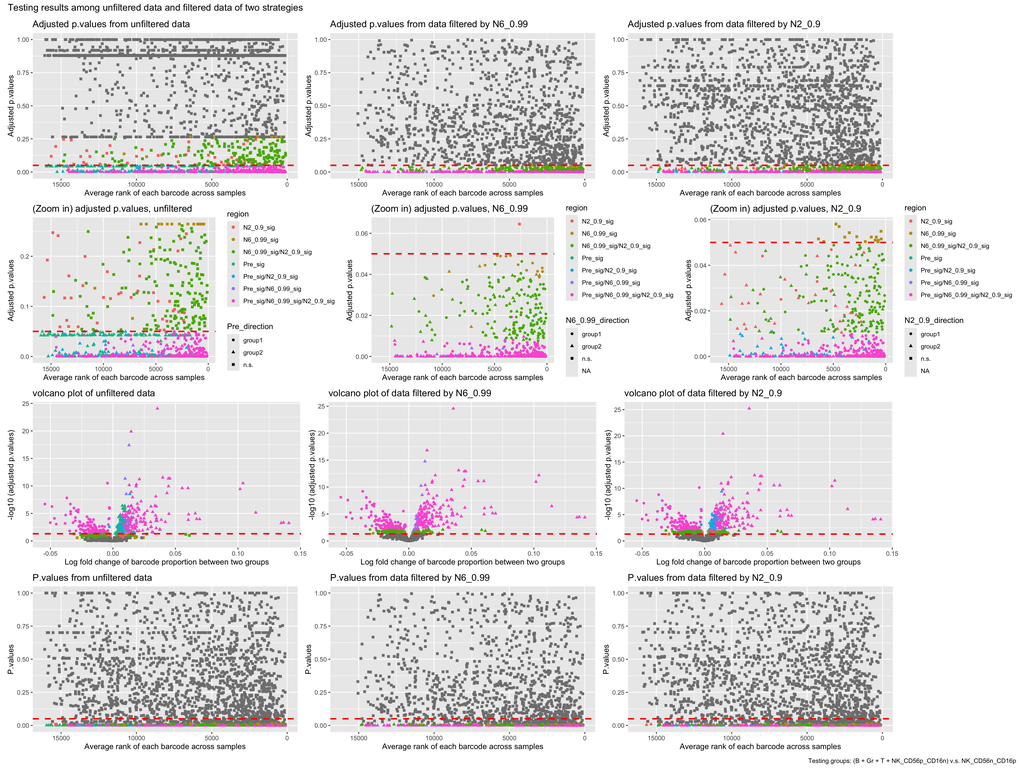

```r
(p11 + p12 + p13) / (p21 + p22 + p23 ) / (p31 + p32 + p33 ) / (p41 + p42 + p43) +
  plot_annotation(title = "Testing results among unfiltered data and filtered data of two strategies",
                  caption = "Testing groups: (B + Gr + T + NK_CD56p_CD16n) v.s. NK_CD56n_CD16p")
```

### 6.2.4 unfiltered v.s. N6_0.99

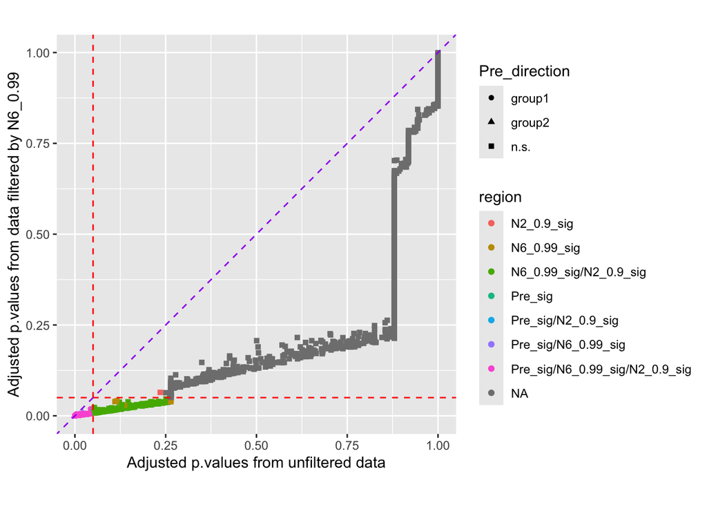

```r
ggplot(results_all) +
  geom_point(aes(x = Pre_adj.p.value, y = N6_0.99_adj.p.value, shape = Pre_direction, color = region)) +
  geom_hline(yintercept = 0.05, color = "red", linetype = "dashed") +
  geom_vline(xintercept = 0.05, color = "red", linetype = "dashed") +
  geom_abline(slope = 1, intercept = 0, color = "purple", linetype = "dashed") +
  theme(aspect.ratio = 1) +
  labs(x = "Adjusted p.values from unfiltered data", y = "Adjusted p.values from data filtered by N6_0.99")
```

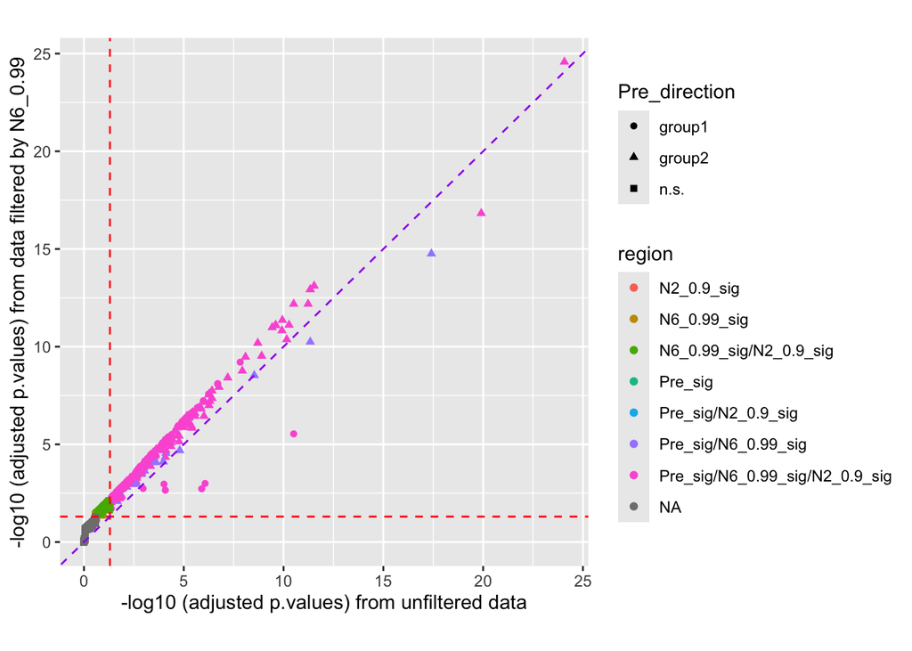

```r
ggplot(results_all) +
  geom_point(aes(x = -log10(Pre_adj.p.value), y = -log10(N6_0.99_adj.p.value), shape = Pre_direction, color = region)) +
  geom_hline(yintercept = -log10(0.05), color = "red", linetype = "dashed") +
  geom_vline(xintercept = -log10(0.05), color = "red", linetype = "dashed") +
  geom_abline(slope = 1, intercept = 0, color = "purple", linetype = "dashed") +
  theme(aspect.ratio = 1) +
  labs(x = "-log10 (adjusted p.values) from unfiltered data", y = "-log10 (adjusted p.values) from data filtered by N6_0.99")
```